# 데이터 사이언스를 위한 소프트웨어 공학

이미지 - `clarifai`

xwMOOC

2019-04-21

# 1 `clarifai` API 서비스

[clarifai](https://clarifai.com/)는 이미지 특화된 서비스를 API 형태로 제공하고 있다. 가격은 월마다 5,000번 작업에 대해서는 무료 그외 `Essential`, `Business`, `Enterprise`, `Public Sector`에 대해서 별도 가격정책을 집행하고 있다. 전자우편을 인증하지 않을 경우 100번 작업으로 호출건수가 제약된다.

# 2 `clarifai` APIKEY 발급 [^1]

가장 먼저, https://clarifai.com/ 웹사이트를 방문하여 회원가입하고 앱을 하나 만들고 인증키를 “GET API KEY”를 통해서 받아낸다.

`usethis::edit_r_environ()` 명령어로 `CLARIFAI_API_KEY`값을 설정하고. 그리고 주석을 달아 다른 API KEY와 혼동되지 않도록 한다. API KEY 설정 결과값은 .Renviron 파일에 저장된다.

# 3 이미지 URL 객체 인식

가장 먼저 http://i.imgur.com/XmAr3jV.jpg 사진 속 강아지를 인식하도록 한다. 이를 위해서 이미지 요청 URL을 JSON 형태로 다음과 같이 준비한다. 그리고 `POST()`로 던져 결과값을 반환받는다.

```r
library(tidyverse)
library(httr)
library(rjson)

# usethis::edit_r_environ()

base_url <- "https://api.clarifai.com/v2/models/aaa03c23b3724a16a56b629203edc62c/outputs"

requests <- '
  {
    "inputs": [
      {
        "data": {
          "image": {
            "url": "http://i.imgur.com/XmAr3jV.jpg"
          }
        }
      }
    ]
  }'

clarifai_res <- POST(base_url,
    add_headers(
        "Authorization" = paste0("Key ", Sys.getenv("CLARIFAI_API_KEY")),
        "Content-Type" = "application/json"),
    body = requests)

clarifai_res
```

```
Response [https://api.clarifai.com/v2/models/aaa03c23b3724a16a56b629203edc62c/outputs]
  Date: 2019-04-21 14:19
  Status: 200
  Content-Type: application/json; charset=UTF-8
  Size: 2.32 kB
```

`for`문을 돌려도 되고 `purrr` 팩키지를 사용해서 결과값을 추출해도 된다.

```r
clarifai_res_parsed <- content(clarifai_res, "parsed")

# for (result in clarifai_res_parsed$outputs[[1]]$data$concepts){
#     message('object: ', result$name, ' -- probability: ', result$value)
# }

clarifai_res_df <- clarifai_res_parsed$outputs[[1]]$data$concepts %>%
  enframe() %>%
  mutate(id = map_chr(value, ~.$id),
         name = map_chr(value, ~.$name),
         value = map_dbl(value, ~.$value))

clarifai_res_df %>%
  DT::datatable()
```

|  | name | value | id |
| --- | --- | --- | --- |
| 1 | 개 | 0.99959356 | ai_8S2Vq3cR |
| 2 | 개과 | 0.9978343 | ai_M6pVRDsX |
| 3 | 애완 동물 | 0.99582434 | ai_gPNNX7LT |
| 4 | 강아지 | 0.9927995 | ai_LRzQhTHd |
| 5 | 귀여운 | 0.99143314 | ai_4CRlSvbV |
| 6 | 포유 동물 | 0.98917997 | ai_N6BnC4br |
| 7 | 우정 | 0.97661877 | ai_H40bd16J |
| 8 | 초상화 | 0.97558284 | ai_TJ9wFfK5 |
| 9 | 국내의 | 0.96942294 | ai_5sqbqWHm |
| 10 | 작은 | 0.9688714 | ai_HkqZwBbr |

[output cut: 10 more lines]

# 4 로컬 컴퓨터 저장된 이미지 [^2]

로컬 컴퓨터에 저장된 이미지를 식별하는데는 다소 다른 방식이 필요하다. `RCurl` 팩키지 `base64Encode` 함수를 사용해서 base64로 인코딩하여 이미지를 불러읽어 처리한다.

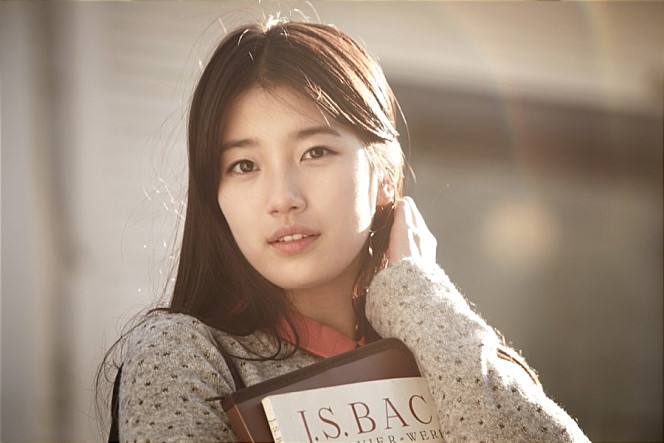

```r
library(RCurl)

suji_res <- POST(base_url,
                body = sprintf('{ "inputs": [{"data": {"image": {"base64": "%s"}}}]}',
                base64Encode(readBin("fig/suji.jpg", "raw", file.info("fig/suji.jpg")[1, "size"])), "txt"),
                add_headers("Authorization" = paste0("Key ", Sys.getenv("CLARIFAI_API_KEY")),
                            "Content-Type" = "application/json"))
suji_res
```

```
Response [https://api.clarifai.com/v2/models/aaa03c23b3724a16a56b629203edc62c/outputs]
  Date: 2019-04-21 14:19
  Status: 200
  Content-Type: application/json; charset=UTF-8
  Size: 2.4 kB
```

로컬 컴퓨터에 저장된 `fig/suji.jpg` 파일을 clarifai 이미지 API에 전송하여 처리한 결과를 다음과 같이 깔금하게 정리한다.

```r
suji_res_parsed <- content(suji_res, "parsed")

suji_res_df <- suji_res_parsed$outputs[[1]]$data$concepts %>%
  enframe() %>%
  mutate(id = map_chr(value, ~.$id),
         name = map_chr(value, ~.$name),
         value = map_dbl(value, ~.$value))

suji_res_df %>%
  DT::datatable()
```

|  | name | value | id |
| --- | --- | --- | --- |
| 1 | 여성 | 0.9879441 | ai_RQccV41p |
| 2 | 옥내에서 | 0.966213 | ai_Pf2b7clG |
| 3 | 사람들 | 0.9441953 | ai_l8TKp2h5 |
| 4 | 예쁜 | 0.94241273 | ai_LsV8BTbr |
| 5 | 유행 | 0.9388894 | ai_dngMN46t |
| 6 | 초상화 | 0.9385966 | ai_TJ9wFfK5 |
| 7 | 분명히 | 0.90743613 | ai_DqkHZlVW |
| 8 | 즐거움 | 0.8682157 | ai_5Nh58JzD |
| 9 | 옥외 | 0.8678536 | ai_Zmhsv0Ch |
| 10 | 즐거움 (쾌락) | 0.8642646 | ai_Bs7Qsx2t |

[output cut: 10 more lines]

[^1]: [Pablo Barbera(August 1, 2018), “Working with the Clarifai API”](http://pablobarbera.com/ECPR-SC104/code/08-clarifai-api.html)
[^2]: [clarifai (2017-03-03) “Access to the new pre-trained models via R”](https://community.clarifai.com/t/access-to-the-new-pre-trained-models-via-r/577)